# Project 25/26 - Αριθμητικές Μέθοδοι στην Επιστήμη των Δεδομένων

Κανίδης Δημήτριος

2026-05-31

```r
# ==============================================================================
# Απεγκατάσταση και φρεσκάρισμα πακέτων
# ==============================================================================

# Αφαιρούμε τυχόν παλαιότερες εκδόσεις των πακέτων
remove.packages(c("curl", "TTR", "quantmod", "psych", "corrplot", "ggplot2", "lavaan", "knitr", "car", "moments"))

# Εγκατάσταση των απαραίτητων πακέτων από την κεντρική πηγή (CRAN)
install.packages("curl", type = "source")
install.packages("TTR", type = "source")
install.packages("quantmod", type = "source")
install.packages("psych", type = "source")
install.packages("corrplot", type = "source")
install.packages("ggplot2", type = "source")
install.packages("lavaan", type = "source")
install.packages("knitr", type = "source")
install.packages("car", type = "source")
install.packages("moments", type = "source")
```

Η απεγκατάσταση και επανεγκατάσταση των πακέτων από το επίσημο site/ CRAN-R Project, έγινε για την αντιμετώπιση προβλημάτων με την παλαιότερη έκδοση της R που έχω εγκατεστημένη στον υπολογιστή μου, εξαιτίας του λογισμικού του (Macintosh 11.7) και της παλαιότερης του έκδοσης, καθώς και για τα ήδη υπάρχοντα φθαρμένα (corrupt) αρχεία που ήδη υπήρχαν.

```r
# 1. Χρήση των πακέτων
library(TTR)
library(quantmod)
library(curl)
# 2. Επιλογή 4ετούς περιόδου
start_date <- "2022-01-01"
end_date   <- "2025-12-31"

# 3. Μετοχές
tickers <- c("DIA",
             "NVDA", "AAPL", "MSFT",
             "BAC", "JPM", "V",
             "GOOGL", "META", "NFLX",
             "AMZN", "TSLA", "HD",
             "LLY", "JNJ", "UNH")

# 4. Λήψη δεδομένων
# Χρησιμοποιούμε το πρόθεμα quantmod:: για να είμαστε 100% σίγουροι ότι η R θα βρει τη συνάρτηση
quantmod::getSymbols(tickers, from = start_date, to = end_date, src = "yahoo")
```

```
##  [1] "DIA"   "NVDA"  "AAPL"  "MSFT"  "BAC"   "JPM"   "V"     "GOOGL" "META"
## [10] "NFLX"  "AMZN"  "TSLA"  "HD"    "LLY"   "JNJ"   "UNH"
```

```r
# 5. Έλεγχος τιμών
print(head(DIA))
```

```
##            DIA.Open DIA.High DIA.Low DIA.Close DIA.Volume DIA.Adjusted
## 2022-01-03   364.34   365.85  362.30    365.68    5624100     338.8043
## 2022-01-04   367.34   369.21  367.21    367.87    5462200     340.8333
## 2022-01-05   367.71   369.50  363.98    364.09    7638000     337.3311
## 2022-01-06   364.11   364.65  361.96    362.39    7019800     335.7561
## 2022-01-07   361.89   363.87  361.13    362.31    5806300     335.6820
## 2022-01-10   361.07   361.22  356.44    360.79    8091800     334.2737
```

```r
# ==============================================================================
# 1.4 Κατασκευή μεταβλητών
# ==============================================================================

# Δημιουργούμε μια συνάρτηση που υπολογίζει τις μεταβλητές για ένα ticker
calculate_returns <- function(ticker_symbol) {

  # 1. Παίρνουμε το αντικείμενο της μετοχής από το περιβάλλον της R
  stock_data <- get(ticker_symbol)

  # 2. Απομονώνουμε τις απαραίτητες στήλες (High, Low, Close)
  Close_t <- Cl(stock_data)
  High_t  <- Hi(stock_data)
  Low_t   <- Lo(stock_data)

  # 3. Υπολογίζουμε το Close της προηγούμενης ημέρας (t-1) χρησιμοποιώντας τη lag()
  Close_lag1 <- lag(Close_t, 1)

  # 4. Εφαρμογή των τύπων της εκφώνησης
  r_t   <- (Close_t / Close_lag1) - 1
  mid_t <- ((Low_t + High_t) / (2 * Close_lag1)) - 1
  rad_t <- (High_t - Low_t) / (2 * Close_lag1)

  # 5. Ενώνουμε τα αποτελέσματα σε έναν πίνακα (xts object) και μετονομάζουμε τις στήλες
  result <- cbind(r_t, mid_t, rad_t)
  colnames(result) <- c(paste0(ticker_symbol, ".r"),
                        paste0(ticker_symbol, ".mid"),
                        paste0(ticker_symbol, ".rad"))

  # Αφαιρούμε των κενών γραμμών
  result <- na.omit(result)

  return(result)
}

# ==============================================================================
# Εφαρμογή σε όλες τις μετοχές
# ==============================================================================

# Δημιουργία λιστών για  αποθήκευση των αποτελεσμάτων
all_returns <- list()

for(ticker in tickers) {
  all_returns[[ticker]] <- calculate_returns(ticker)
}

# Παράδειγμα ελέγχου: Εμφάνιση των πρώτων γραμμών των νέων μεταβλητών για το ETF DIA
cat("Οι νέες μεταβλητές (r, mid, rad) για το DIA:\n")
```

```
## Οι νέες μεταβλητές (r, mid, rad) για το DIA:
```

```r
print(head(all_returns[["DIA"]]))
```

```
##                    DIA.r      DIA.mid     DIA.rad
## 2022-01-04  0.0059888495  0.006918614 0.002734631
## 2022-01-05 -0.0102753658 -0.003071709 0.007502636
## 2022-01-06 -0.0046691250 -0.002156070 0.003694145
## 2022-01-07 -0.0002208038  0.000303500 0.003780444
## 2022-01-10 -0.0041952721 -0.009605023 0.006596559
## 2022-01-11  0.0048504669 -0.001566015 0.006998514
```

```r
# Δημιουργία  CSV αρχείων
Y_variable <- all_returns[["DIA"]][, "DIA.mid"]
X_list <- list()
for(ticker in tickers[-1]) {
  X_list[[ticker]] <- all_returns[[ticker]][, paste0(ticker, ".mid")]
}
X_variables_A <- as.data.frame(do.call(cbind, X_list))
colnames(X_variables_A) <- tickers[-1]

df_for_plots <- data.frame(DIA = Y_variable, X_variables_A)
write.csv(df_for_plots, file = "returns_data.csv", row.names = TRUE)

final_dataset <- do.call(cbind, all_returns)
write.csv(as.data.frame(final_dataset), file = "complete_project_data.csv", row.names = TRUE)
current_path <- getwd()
```

Στο παραπάνω κομμάτι κώδικα, εκτός από την κατασκευή των μεταβλητών, όπως έχει ζητηθεί στην εκφώνηση, έχουμε “πετάξει” όλες τις κενές τιμές των 16 μεταβλητών, χρησιμοποιώντας την εντολή result <- na.omit(result). Επίσης έχουμε δημιουργήσει τα αρχεία CSV με τις αρχικές μεταβλητές των μετοχών και με τις μεταβλητές που κατασκευάσαμε και μέσω της εντολής current_path<- getwd() φαίνεται δεξιά στο “Enviroment” πού ακριβώς έχουν αποθηκευτεί. Τα δεδομένα έχουν κατέβει και αυτόματα.

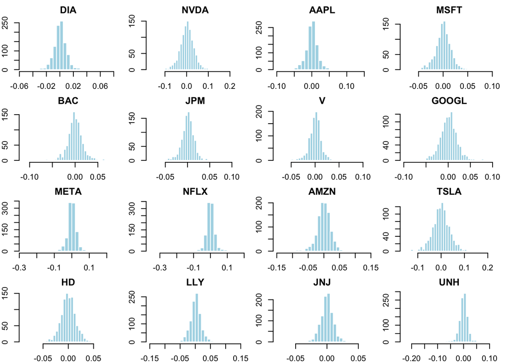

```r
# ==============================================================================
# Α1: Περιγραφική στατιστική
# ==============================================================================

# 1.Φόρτωση του πακέτου 'moments' για skewness & kurtosis
library(moments)

# 2. Συγκέντρωση όλων των κλασικών αποδόσεων (r) σε ένα μεγάλο data frame
classic_returns_list <- list()
for(ticker in tickers) {
  classic_returns_list[[ticker]] <- all_returns[[ticker]][, paste0(ticker, ".r")]
}

# Ενοποίηση των στηλών σε ένα αντικείμενο
classic_returns_df <- do.call(cbind, classic_returns_list)
# Μετονομασία στηλών για να είναι πιο καθαρές
colnames(classic_returns_df) <- tickers

# Μετατροπή σε κλασικό data frame για ευκολότερη διαχείριση στα plots
df_for_plots <- as.data.frame(classic_returns_df)

# ==============================================================================
# 3. Διαγράμματα (Ιστογράμματα & Boxplots)
# ==============================================================================

# Ρύθμιση του παραθύρου για να δείχνει πολλά γραφήματα μαζί (π.χ. 4x4)
par(mfrow = c(4, 4), mar = c(2, 2, 2, 1))

# Α) Σχεδίαση Ιστογραμμάτων για όλες τις μεταβλητές
for(ticker in tickers) {
  hist(df_for_plots[[ticker]], main = ticker, col = "lightblue",
       breaks = 30, xlab = "Returns", border = "white")
}
```

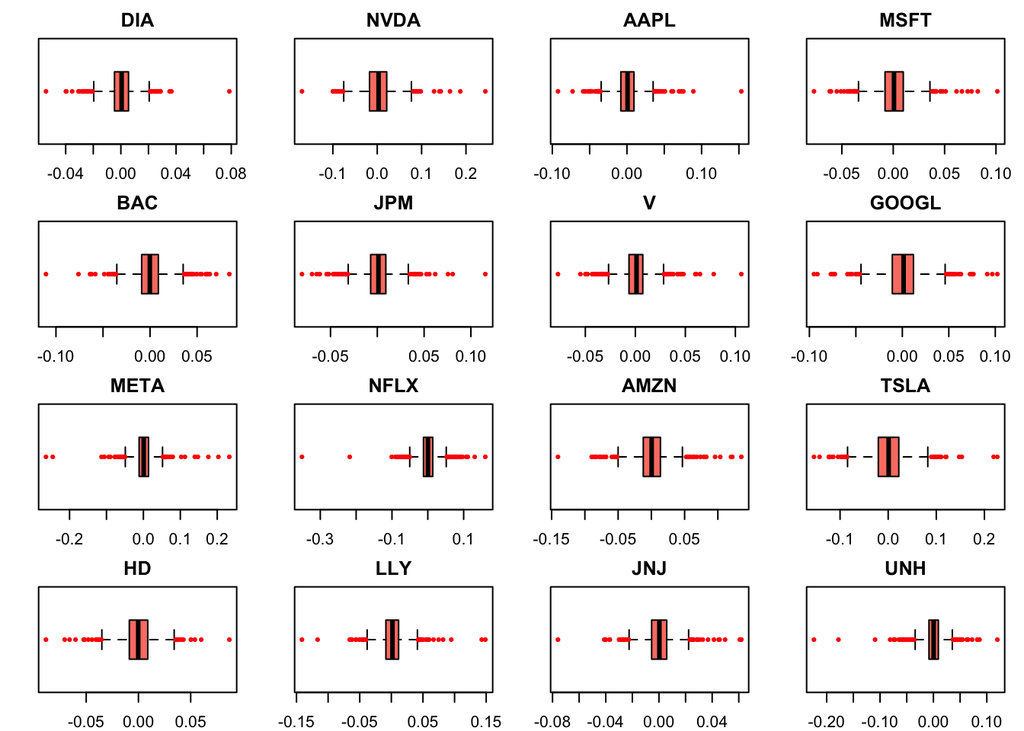

```r
# Β) Σχεδίαση Boxplots για όλες τις μεταβλητές
for(ticker in tickers) {
  boxplot(df_for_plots[[ticker]], main = ticker, col = "salmon",
          horizontal = TRUE, outcol = "red", outpch = 20)
}
```

```r
# Επαναφορά των ρυθμίσεων των γραφημάτων στο κανονικό (1x1)
par(mfrow = c(1, 1))

# ==============================================================================
# 4. Πίνακας περιγραφικής στατιστικής
# ==============================================================================

# Δημιουργία ενός κενού πίνακα για τα αποτελέσματα
stats_table <- data.frame(
  Ticker = character(),
  Mean = numeric(),
  Median = numeric(),
  Std_Dev = numeric(),
  Skewness = numeric(),
  Kurtosis = numeric(),
  stringsAsFactors = FALSE
)

# Υπολογισμός των δεικτών για κάθε ticker
for(ticker in tickers) {
  x <- df_for_plots[[ticker]]

  stats_table <- rbind(stats_table, data.frame(
    Ticker = ticker,
    Mean = mean(x),
    Median = median(x),
    Std_Dev = sd(x),
    Skewness = skewness(x),
    Kurtosis = kurtosis(x)
  ))
}

# Στρογγυλοποίηση των αποτελεσμάτων σε 5 δεκαδικά ψηφία
stats_table[, 2:6] <- round(stats_table[, 2:6], 5)

# Εμφάνιση του τελικού πίνακα
print(stats_table)
```

```
##    Ticker     Mean   Median Std_Dev Skewness Kurtosis
## 1     DIA  0.00033  0.00054 0.00961  0.19381  9.38868
## 2    NVDA  0.00240  0.00301 0.03397  0.53814  7.71889
## 3    AAPL  0.00057  0.00079 0.01797  0.54946 10.36312
## 4    MSFT  0.00052  0.00073 0.01688  0.24672  6.32622
## 5     BAC  0.00033 -0.00024 0.01726 -0.00275  6.81978
## 6     JPM  0.00082  0.00123 0.01578  0.11704  8.73834
## 7       V  0.00057  0.00118 0.01406  0.36160  9.61940
## 8   GOOGL  0.00098  0.00136 0.02058  0.08354  5.92822
## 9    META  0.00111  0.00083 0.02916 -0.19895 23.02858
## 10   NFLX  0.00089  0.00033 0.02882 -1.75592 30.21187
## 11   AMZN  0.00059  0.00042 0.02356  0.16662  7.72808
## 12   TSLA  0.00088  0.00097 0.03896  0.28712  5.83728
## 13     HD -0.00005 -0.00021 0.01545 -0.18856  6.08304
## 14    LLY  0.00158  0.00178 0.02019  0.27591 12.24774
## 15    JNJ  0.00025  0.00033 0.01088  0.13385  8.38250
## 16    UNH -0.00021  0.00041 0.02004 -2.06117 27.55793
```

```r
# ==============================================================================
# Α2. Πίνακας συσχετίσεων και πολυσυγγραμικότητα
# ==============================================================================

# 1. Εγκατάσταση και φόρτωση των απαραίτητων πακέτων
if(!require(car)) install.packages("car")
```

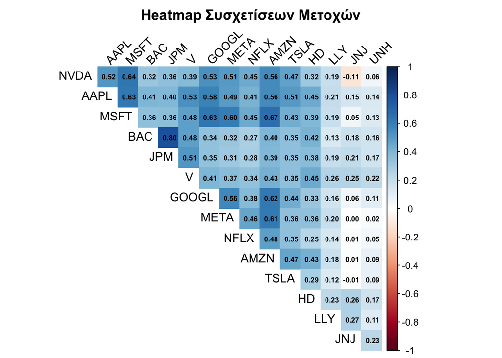

```r
if(!require(corrplot)) install.packages("corrplot")
library(car)
library(corrplot)

# Απομονώνουμε μόνο τις 15 ανεξάρτητες μεταβλητές (δηλαδή χωρίς το DIA)
X_variables <- df_for_plots[, tickers[-1]]

# 2. Υπολογισμός του πίνακα συσχετίσεων
cor_matrix <- cor(X_variables)

# 3. Σχεδίαση του πίνακα
corrplot(cor_matrix, method = "color", type = "upper",
         tl.col = "black", tl.srt = 45,
         addCoef.col = "black", number.cex = 0.6, # Εμφάνιση των αριθμών συσχέτισης
         diag = FALSE, title = "Heatmap Συσχετίσεων Μετοχών", mar = c(0,0,2,0))
```

```r
# ==============================================================================
# 4. Εντοπισμός ζευγαριών με |r| > 0.8
# ==============================================================================
cat("\n--- Ζεύγη μετοχών με απόλυτη συσχέτιση |r| > 0.8 ---\n")
```

```
##
## --- Ζεύγη μετοχών με απόλυτη συσχέτιση |r| > 0.8 ---
```

```r
high_cor_found <- FALSE

for(i in 1:(ncol(cor_matrix)-1)) {
  for(j in (i+1):ncol(cor_matrix)) {
    if(abs(cor_matrix[i,j]) > 0.8) {
      cat(rownames(cor_matrix)[i], "-", colnames(cor_matrix)[j], ":", round(cor_matrix[i,j], 4), "\n")
      high_cor_found <- TRUE
    }
  }
}
if(!high_cor_found) cat("Δεν βρέθηκαν ζεύγη με |r| > 0.8\n")
```

```
## Δεν βρέθηκαν ζεύγη με |r| > 0.8
```

```r
# ==============================================================================
# 5. Υπολογισμός VIF (Variance Inflation Factor)
# ==============================================================================
# Για να υπολογίσουμε το VIF, πρέπει πρώτα να τρέξουμε μια πρόχειρη γραμμική παλινδρόμηση
# όπου εξαρτημένη μεταβλητή είναι το DIA και ανεξάρτητες οι 15 μετοχές.
lm_for_vif <- lm(DIA ~ ., data = df_for_plots)

# Υπολογισμός VIF
vif_values <- vif(lm_for_vif)

# Μετατροπή σε data frame
vif_table <- data.frame(
  Ticker = names(vif_values),
  VIF = round(vif_values, 4)
)

cat("\n--- Πίνακας Τιμών VIF ---\n")
```

```
##
## --- Πίνακας Τιμών VIF ---
```

```r
print(vif_table)
```

```
##       Ticker    VIF
## NVDA    NVDA 2.1300
## AAPL    AAPL 2.2699
## MSFT    MSFT 2.7462
## BAC      BAC 2.9838
## JPM      JPM 3.0398
## V          V 1.8417
## GOOGL  GOOGL 2.1402
## META    META 1.9906
## NFLX    NFLX 1.4812
## AMZN    AMZN 2.4949
## TSLA    TSLA 1.5633
## HD        HD 1.5485
## LLY      LLY 1.1730
## JNJ      JNJ 1.3352
## UNH      UNH 1.1089
```

Σχετικά με την πολυσυγγραμικότητα, δεν υπάρχει καμία τιμή που να υποδηλώνει, έντονη πολυσυγγραμικότητα, καθώς όλες οι τιμές βρίσκονται κάτω από το 5, σε όλες τις ανεξάρτητες μεταβλητές.

```r
# ==============================================================================
# Α3. Factor Analysis
# ==============================================================================

# 1. Εγκατάσταση και φόρτωση του πακέτου 'psych'
if(!require(psych)) install.packages("psych")
library(psych)

# Χρησιμοποιούμε μόνο τις 15 μετοχές (X_variables)
# (Χωρίς το ETF DIA)

cat("--- 1. 'Ελεγχοι καταλληλότητας δεδομένων (KMO & BARTLETT) ---\n")
```

```
## --- 1. 'Ελεγχοι καταλληλότητας δεδομένων (KMO & BARTLETT) ---
```

```r
# Bartlett's Test
bartlett_test <- cortest.bartlett(cor(X_variables), n = nrow(X_variables))
print(bartlett_test)
```

```
## $chisq
## [1] 6592.95
##
## $p.value
## [1] 0
##
## $df
## [1] 105
```

```r
#KMO (Kaiser-Meyer-Olkin) Test
kmo_test <- KMO(X_variables)
print(kmo_test)
```

```
## Kaiser-Meyer-Olkin factor adequacy
## Call: KMO(r = X_variables)
## Overall MSA =  0.91
## MSA for each item =
##  NVDA  AAPL  MSFT   BAC   JPM     V GOOGL  META  NFLX  AMZN  TSLA    HD   LLY
##  0.92  0.94  0.92  0.79  0.79  0.95  0.94  0.94  0.95  0.94  0.94  0.93  0.85
##   JNJ   UNH
##  0.65  0.85
```

```r
cat("--- 2. Προσδιορισμός πλήθους παραγόντων (Scree Plot)) ---\n")
```

```
## --- 2. Προσδιορισμός πλήθους παραγόντων (Scree Plot)) ---
```

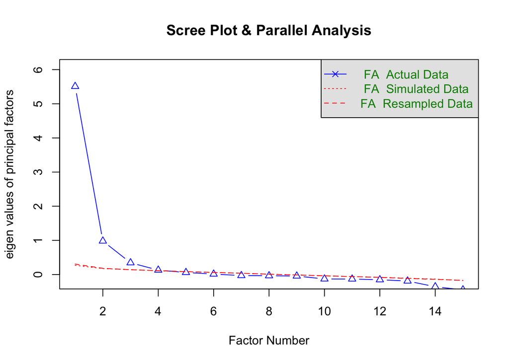

```
## Parallel analysis suggests that the number of factors =  4  and the number of components =  NA
```

```r
# Σχεδίαση Scree Plot για να δούμε οπτικά πόσοι παράγοντες έχουν Eigenvalue > 1
fa.parallel(X_variables, fm = "pa", fa = "fa", main = "Scree Plot & Parallel Analysis")
```

```r
cat("\n--- 3. Factor Analysis (Principal Axis Factoring & Varimax) ---\n")
```

```
##
## --- 3. Factor Analysis (Principal Axis Factoring & Varimax) ---
```

```r
fa_result <- fa(X_variables, nfactors = 3, fm = "pa", rotate = "varimax")

# Εμφάνιση των "φορτίσεων" (Factor Loadings)
# Κρύβουμε τις φορτίσεις κάτω από 0.3 για να είναι ευανάγνωστος ο πίνακας
print(fa_result$loadings, cut = 0.3)
```

```
##
## Loadings:
##       PA1    PA2    PA3
## NVDA   0.733
## AAPL   0.679         0.300
## MSFT   0.802
## BAC           0.841
## JPM           0.797
## V      0.445  0.346  0.427
## GOOGL  0.720
## META   0.707
## NFLX   0.557
## AMZN   0.772
## TSLA   0.543
## HD     0.383         0.407
## LLY                  0.361
## JNJ                  0.720
## UNH                  0.323
##
##                  PA1   PA2   PA3
## SS loadings    4.403 1.776 1.374
## Proportion Var 0.294 0.118 0.092
## Cumulative Var 0.294 0.412 0.504
```

Αφού το p-value στο Bartlett test είναι 0, δηλαδή χαμηλότερο του 0.05, και αφού στο KMO test, έχουμε συνολικό MSA = 0.91, το οποίο είναι πολύ κοντά στο 1, καταλήγουμε στο συμπεράσμα ότι τα δεδομένα είναι κατάλληλα για Factor Analysis.

Factor Analysis: Από την διαδικασία του Factor Analysis, εξάχθηκαν 3 διαφορετικοί παράγοντες, PA1, PA2 & PA3. Ο πρώτος παράγοντας (PA1) περιλαμβάνει με μεγάλες τιμές τις μετοχές που σχετίζονται με τον τεχνολογικό τομέα όπως η Microsoft, η Apple και η Tesla. Ο δεύτερος παράγοντας περιλαμβάνει τις μετοχές που σχετίζονται με τον χρηματοοικονομικό τομέα, όπως η Bank Of America (BAC) και η JPMorgan Chase (JPM). Ο τρίτος και τελευταίος παράγοντας (PA3) περιλαμβάνει τις μετοχές του τομέα τις υγείας (Johnson & Johnson (JNJ), Home Depot (HD)). Αυτή η “ομαδοποίηση” των παραγόντων δείχνει ότι οι μετοχές διαφορετικών τομέων, τείνουν να κινούνται ανεξάρτητα από τις υπόλοιπες μετοχές. Για παράδειγμα, η Apple δεν επηρεάζει τις μετοχές της Johnson & Johnson σε μεγάλο βαθμό, ενώ επηρεάζει πιο εντόνα τις μετοχές της Google.

```r
# ==============================================================================
# A4. Principal Component Analysis (PCA)
# ==============================================================================

# 1. PCA στις 15 ανεξάρτητες μετοχές (X_variables)
# scale. = TRUE είναι εξαιρετικά σημαντικό για να έχουν όλες οι μετοχές το ίδιο βάρος
pca_result <- prcomp(X_variables, center = TRUE, scale. = TRUE)

# 2. Ιδιοτιμές (Eigenvalues)
# Στην PCA οι ιδιοτιμές προκύπτουν από το τετράγωνο των τυπικών αποκλίσεων (sdev)
eigenvalues <- pca_result$sdev^2

cat("--- 1. Ιδιοτιμές (eigenvalues) και κριτήριο Kaiser ---\n")
```

```
## --- 1. Ιδιοτιμές (eigenvalues) και κριτήριο Kaiser ---
```

```r
for(i in 1:length(eigenvalues)) {
  cat(paste0("Component ", i, ": Eigenvalue = ", round(eigenvalues[i], 4), "\n"))
}
```

```
## Component 1: Eigenvalue = 6.0475
## Component 2: Eigenvalue = 1.7063
## Component 3: Eigenvalue = 1.091
## Component 4: Eigenvalue = 0.8931
## Component 5: Eigenvalue = 0.746
## Component 6: Eigenvalue = 0.6851
## Component 7: Eigenvalue = 0.6548
## Component 8: Eigenvalue = 0.6111
## Component 9: Eigenvalue = 0.5401
## Component 10: Eigenvalue = 0.4478
## Component 11: Eigenvalue = 0.3965
## Component 12: Eigenvalue = 0.3725
## Component 13: Eigenvalue = 0.3449
## Component 14: Eigenvalue = 0.2722
## Component 15: Eigenvalue = 0.1912
```

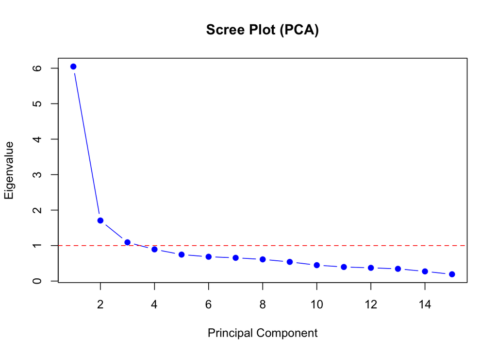

```r
# 3. Scree Plot
plot(eigenvalues, type = "b", pch = 19, xlab = "Principal Component",
     ylab = "Eigenvalue", main = "Scree Plot (PCA)", col = "blue")
abline(h = 1, col = "red", lty = 2) # Γραμμή για το κριτήριο Kaiser (>1)
```

```r
# 4. Ποσοστό Διασποράς (Explained Variance)
pca_summary <- summary(pca_result)
cat("\n--- 2. Ποσοστό διασποράς που εξηγείται ---\n")
```

```
##
## --- 2. Ποσοστό διασποράς που εξηγείται ---
```

```r
print(pca_summary$importance)
```

```
##                             PC1      PC2      PC3       PC4       PC5       PC6
## Standard deviation     2.459165 1.306255 1.044502 0.9450517 0.8637154 0.8277193
## Proportion of Variance 0.403170 0.113750 0.072730 0.0595400 0.0497300 0.0456700
## Cumulative Proportion  0.403170 0.516920 0.589650 0.6491900 0.6989300 0.7446000
##                              PC7       PC8       PC9      PC10      PC11
## Standard deviation     0.8091888 0.7817356 0.7349032 0.6691695 0.6296919
## Proportion of Variance 0.0436500 0.0407400 0.0360100 0.0298500 0.0264300
## Cumulative Proportion  0.7882500 0.8289900 0.8650000 0.8948500 0.9212900
##                             PC12      PC13      PC14      PC15
## Standard deviation     0.6102923 0.5872742 0.5216902 0.4372492
## Proportion of Variance 0.0248300 0.0229900 0.0181400 0.0127500
## Cumulative Proportion  0.9461200 0.9691100 0.9872500 1.0000000
```

```r
# 5. Ερμηνεία των πρώτων Components (Loadings / Rotation)
cat("\n--- 3. Φορτίσεις των πρώτων δύο components (Loadings) ---\n")
```

```
##
## --- 3. Φορτίσεις των πρώτων δύο components (Loadings) ---
```

```r
print(round(pca_result$rotation[, 1:2], 4))
```

```
##          PC1     PC2
## NVDA  0.2926  0.2504
## AAPL  0.3177  0.0244
## MSFT  0.3259  0.1655
## BAC   0.2603 -0.2912
## JPM   0.2629 -0.3053
## V     0.2812 -0.2319
## GOOGL 0.3020  0.1664
## META  0.2888  0.2127
## NFLX  0.2432  0.1775
## AMZN  0.3222  0.1728
## TSLA  0.2555  0.1156
## HD    0.2446 -0.2291
## LLY   0.1298 -0.2368
## JNJ   0.0687 -0.5457
## UNH   0.0839 -0.3514
```

Όπως επιβεβαιώνετε και από το Scree Plot, οι πρώτες 3 συνιστώσες είναι οι μόνες που έχουν ιδιοτιμή μεγαλύτερη του 1. Αυτό σημαίνει ότι αυτές οι 3 πρώτες συνιστώσες, έχουν το πλήθος της πληροφορίας, ενώ οι υπόλοιπες συνιστώσες είναι λιγότερο σημαντικές. Μέσω του κριτηρίου Kaiser, μπορούμε να απλοποιήσουμε το μοντέλο και να το κάνουμε πιο ερμηνεύσιμο, χωρίς όμως να χαθεί η σημασία του, αφού κρατάμε αρκετά μεγάλο αριθμό της πληροφορίας.

Για τα πρώτα 2 components, παρατηρούμε ότι όλες οι μετοχές έχουν θετικό πρόσημο στο πρώτο component (PC1), ενώ στο δεύτερο component (PC2), υπάρχουν και θετικά και αρνητικά πρόσημα. Το PC1, το οποίο ερμηνεύει το 40% της συνολικής διασποράς, αντικατοπτρίζει την γενικότερη κίνηση όλης της αγοράς από κοινού, και πώς αυτή η συνολική άνοδος επηρεάζει κάθε μετοχή ξεχωριστά. Το PC2, το οποίο ερμηνεύει μόνο το 11% της συνολικής διασποράς, δείχνει την αντίθεση μεταξύ των διαφορετικών οικονομικών κλάδων, και πώς η άνοδος στον ένα κλάδο μπορεί να οδηγήσει σε πτώση των τιμών σε μια μετοχή ένος διαφορετικού κλάδου.

```r
# ==============================================================================
# Α5. Γραμμική παλινδρόμηση και stepwise simplification.
# ==============================================================================

# 1. Μέγιστο υπόδειγμα (Full Model) - Ήδη ορισμένο ως classic_model στο Α3
full_model <- lm(DIA ~ ., data = df_for_plots)

# 2. Stepwise Selection (Both directions) με βάση το AIC
optimal_model <- step(full_model, direction = "both", trace = 0)

cat("--- 1. Ελάχιστα επαρκές υπόδειγμα (Minimal Adequate Model) ---\n")
```

```
## --- 1. Ελάχιστα επαρκές υπόδειγμα (Minimal Adequate Model) ---
```

```r
summary_optimal <- summary(optimal_model)
print(summary_optimal)
```

```
##
## Call:
## lm(formula = DIA ~ NVDA + AAPL + MSFT + BAC + JPM + V + AMZN +
##     HD + LLY + JNJ + UNH, data = df_for_plots)
##
## Residuals:
##        Min         1Q     Median         3Q        Max
## -0.0146587 -0.0018930 -0.0000233  0.0018913  0.0146220
##
## Coefficients:
##               Estimate Std. Error t value Pr(>|t|)
## (Intercept) -4.134e-05  1.015e-04  -0.407 0.683916
## NVDA         1.522e-02  4.197e-03   3.626 0.000303 ***
## AAPL         8.166e-02  8.041e-03  10.155  < 2e-16 ***
## MSFT         7.948e-02  9.514e-03   8.354  < 2e-16 ***
## BAC          8.475e-02  1.007e-02   8.415  < 2e-16 ***
## JPM          1.350e-01  1.113e-02  12.127  < 2e-16 ***
## V            1.058e-01  9.710e-03  10.898  < 2e-16 ***
## AMZN         2.827e-02  6.234e-03   4.534 6.49e-06 ***
## HD           1.297e-01  8.084e-03  16.048  < 2e-16 ***
## LLY          1.894e-02  5.396e-03   3.511 0.000467 ***
## JNJ          8.683e-02  1.066e-02   8.143 1.15e-15 ***
## UNH          8.411e-02  5.276e-03  15.943  < 2e-16 ***
## ---
## Signif. codes:  0 '***' 0.001 '**' 0.01 '*' 0.05 '.' 0.1 ' ' 1
##
## Residual standard error: 0.00319 on 989 degrees of freedom
## Multiple R-squared:  0.891,  Adjusted R-squared:  0.8897
## F-statistic: 734.7 on 11 and 989 DF,  p-value: < 2.2e-16
```

```r
# ==============================================================================
# 3. Διαγνωστικοί έλεγχοι (Diagnostic Plots & Heteroskedasticity)
# ==============================================================================
cat("\n--- 2. Διαγνωστικοί έλεγχοι καταλοίπων ---\n")
```

```
##
## --- 2. Διαγνωστικοί έλεγχοι καταλοίπων ---
```

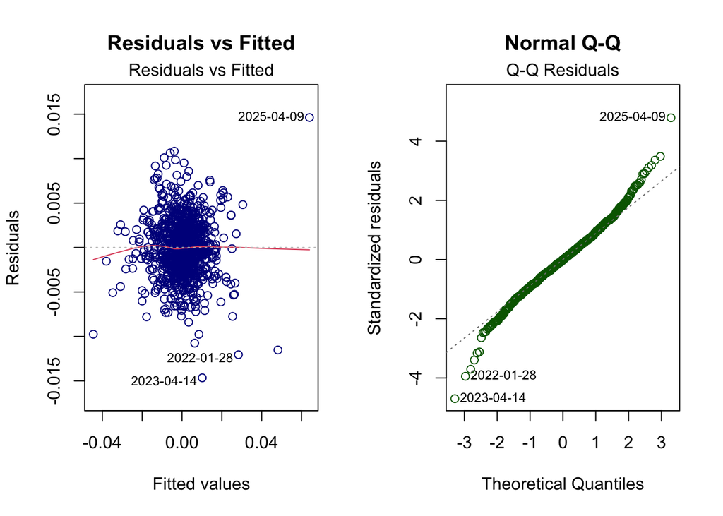

```r
# Ρύθμιση για να εμφανιστούν 2 γραφήματα δίπλα-δίπλα
par(mfrow = c(1, 2))

# Residuals vs Fitted Plot (Έλεγχος γραμμικότητας και σταθερής διακύμανσης)
plot(optimal_model, which = 1, col = "darkblue", main = "Residuals vs Fitted")

# Normal Q-Q Plot (Έλεγχος κανονικότητας των καταλοίπων)
plot(optimal_model, which = 2, col = "darkgreen", main = "Normal Q-Q")
```

```r
# Επαναφορά του σχεδιαστικού περιβάλλοντος στο κανονικό
par(mfrow = c(1, 1))

# Στατιστικός Έλεγχος Ετεροσκεδαστικότητας (Breusch-Pagan Test)
if(!require(lmtest)) install.packages("lmtest")
library(lmtest)

bp_test <- bptest(optimal_model)
cat("\nBreusch-Pagan Test για Ετεροσκεδαστικότητα:\n")
```

```
##
## Breusch-Pagan Test για Ετεροσκεδαστικότητα:
```

```r
print(bp_test)
```

```
##
##  studentized Breusch-Pagan test
##
## data:  optimal_model
## BP = 35.096, df = 11, p-value = 0.0002389
```

Κατάλοιπα: Από τους ελέγχους και τα διαγράμματα που έχουν γίνει στην R, μπορούμε να συμπεράνουμε ότι ισχύει η υπόθεση της ετεροσκεδαστικότητας τον καταλοίπων, αφού στον έλεγχο Breusch-Pagan, έχουμε p-value = 0.0002389 < 0.05. Όσον αφορά την κανονικότητα των καταλοίπων, παρατηρούμε από το διάγραμμα Normal Q-Q Plot, ότι οι περισσότερες τιμές από τα κατάλοιπα βρίσκονται πάνω στην ευθεία διακεκκομένη γραμμή, άρα φαίνεται ότι η πλειοψηφία των καταλοίπων ακολουθούν την κανονική κατανομή. Όμως, στις πιο ακραίες περιπτώσεις, παρατηρούμε ότι οι τιμές των καταλοίπων ξεφεύγουν πολύ από την διακεκκομένη γραμμή. Συνολικά. μπορούμε να εξάγουμε το συμπέρασμα ότι η συντριπτική πλειοψηφία των καταλοίπων των παρατηρήσεων, ακολουθεί την κανονική κατανομή.

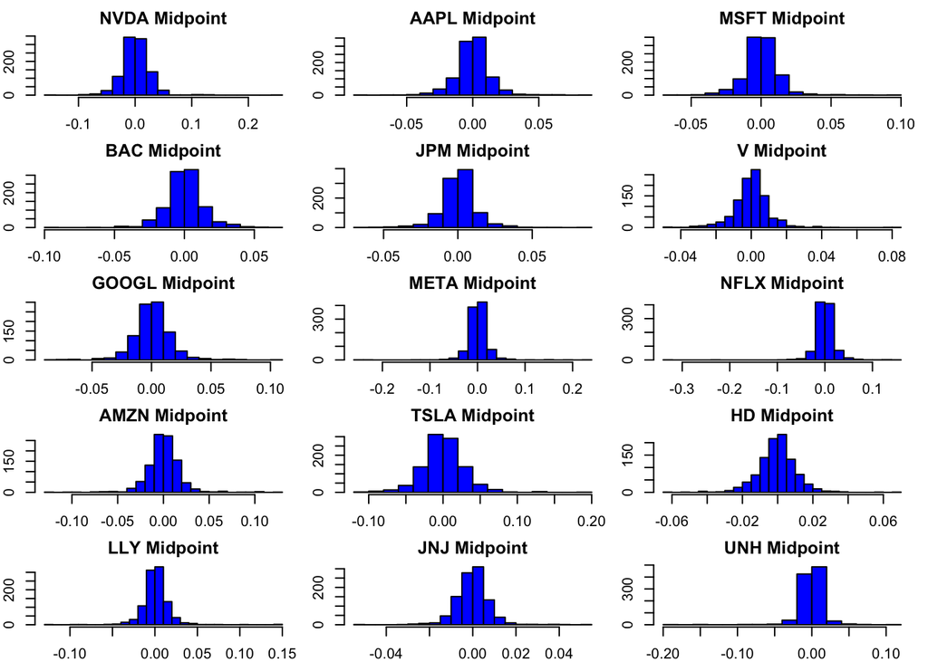

```r
# ==============================================================================
# B1: Περιγραφή διαστηματικών δεδομένων
# ==============================================================================

# Διαχωρισμός Midpoints και Radii σε Data Frames για τις 15 μετοχές (X variables)
mid_list <- list()
rad_list <- list()

for(ticker in tickers[-1]) {
  mid_list[[ticker]] <- all_returns[[ticker]][, paste0(ticker, ".mid")]
  rad_list[[ticker]] <- all_returns[[ticker]][, paste0(ticker, ".rad")]
}

df_mid <- as.data.frame(do.call(cbind, mid_list))
df_rad <- as.data.frame(do.call(cbind, rad_list))
colnames(df_mid) <- tickers[-1]
colnames(df_rad) <- tickers[-1]


# Ιστογράμματα για όλα τα Midpoints
# Ορίζουμε ένα πλέγμα 5 γραμμών και 3 στηλών (5*3 = 15 γραφήματα μαζί)
par(mfrow = c(5, 3), mar = c(2, 2, 2, 1))
for(ticker in tickers[-1]) {
  hist(df_mid[, ticker], breaks = 20, col = "blue",
       main = paste(ticker, "Midpoint"), xlab = "", ylab = "")
}
```

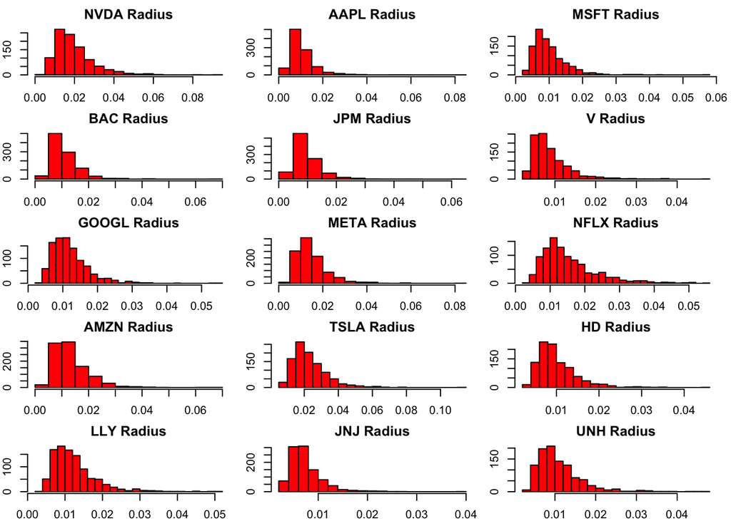

```r
par(mfrow = c(1, 1)) # Επαναφορά περιβάλλοντος

# Ιστογράμματα για όλα τα Radii
par(mfrow = c(5, 3), mar = c(2, 2, 2, 1))
for(ticker in tickers[-1]) {
  hist(df_rad[, ticker], breaks = 20, col = "red",
       main = paste(ticker, "Radius"), xlab = "", ylab = "")
}
```

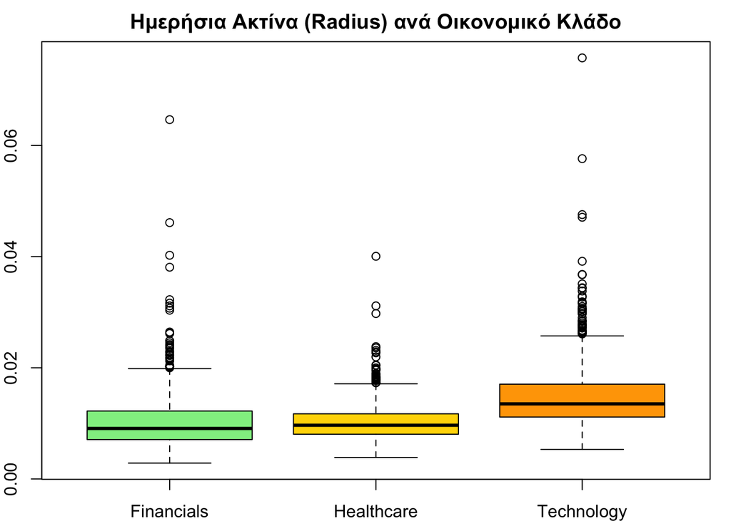

```r
par(mfrow = c(1, 1)) # Επαναφορά περιβάλλοντος

# ------------------------------------------------------------------------------
# Boxplots rad ανά κλάδο (Βάσει των 3 κλάδων που βρήκαμε σε FA/PCA)
# ------------------------------------------------------------------------------

# Δημιουργούμε τους 3 κλάδους υπολογίζοντας τον μέσο όρο των Radii των μετοχών τους
tech_rad  <- rowMeans(df_rad[, c("MSFT", "AMZN", "NVDA", "GOOGL", "META", "AAPL", "NFLX", "TSLA")])
fin_rad   <- rowMeans(df_rad[, c("BAC", "JPM")])
def_rad   <- rowMeans(df_rad[, c("JNJ", "HD", "LLY", "UNH")]) # Υγεία

# Κατασκευή Data Frame για το Boxplot
sector_rad_df <- data.frame(
  Radius = c(tech_rad, fin_rad, def_rad),
  Sector = rep(c("Technology", "Financials", "Healthcare"), each = length(tech_rad))
)

# Σχεδίαση Boxplot ανά Κλάδο (Τεχνολογία/Οικονομία/Υγεία)
boxplot(Radius ~ Sector, data = sector_rad_df, col = c("lightgreen", "gold", "orange"),
        main = "Ημερήσια Ακτίνα (Radius) ανά Οικονομικό Κλάδο",
        ylab = "Radius (Μεταβλητότητα)", xlab = "Κλάδος")
```

```r
# ------------------------------------------------------------------------------
# Πίνακας συσχετίσεων μεταξύ mid και rad
# ------------------------------------------------------------------------------

cat("==================================================================\n")
cat("Πίνακας συσχετίσεων μεταξύ κέντρων (mid) και ακτίνων (rad))\n")
```

```
## Πίνακας συσχετίσεων μεταξύ κέντρων (mid) και ακτίνων (rad))
```

```r
cat("==================================================================\n")
# Υπολογίζουμε τη συσχέτιση ανάμεσα σε ολόκληρο το df_mid και το df_rad
# Πίνακας 15x15 όπου οι γραμμές είναι τα Mid και οι στήλες τα Rad
cor_mid_vs_rad <- cor(df_mid, df_rad)

print(round(cor_mid_vs_rad, 4))
```

```
##          NVDA    AAPL    MSFT     BAC     JPM       V   GOOGL    META    NFLX
## NVDA  -0.0132 -0.0335 -0.0423 -0.0304 -0.0379 -0.0442 -0.0002 -0.0412  0.0020
## AAPL  -0.0293  0.0150 -0.0316 -0.0351 -0.0016 -0.0290 -0.0155 -0.0167 -0.0329
## MSFT  -0.0353  0.0042  0.0315  0.0051  0.0282 -0.0194  0.0043  0.0166 -0.0046
## BAC   -0.0810 -0.0568 -0.0636 -0.0349 -0.0433 -0.0881 -0.0393 -0.0544 -0.0371
## JPM   -0.0493 -0.0252 -0.0586 -0.0184 -0.0273 -0.0763 -0.0201 -0.0279 -0.0274
## V      0.0136  0.0152 -0.0249 -0.0414 -0.0036 -0.0593  0.0065  0.0260  0.0009
## GOOGL -0.0165 -0.0181 -0.0596 -0.0135  0.0018 -0.0241  0.0273 -0.0024 -0.0046
## META  -0.0066  0.0143 -0.0044 -0.0069 -0.0211 -0.0215 -0.0126  0.1073 -0.0061
## NFLX  -0.0486 -0.0081 -0.0333  0.0027 -0.0155 -0.0438 -0.0537 -0.0564  0.0356
## AMZN  -0.0946 -0.0832 -0.0935 -0.0324 -0.0357 -0.0954 -0.0365 -0.0243 -0.0351
## TSLA  -0.0898 -0.0618 -0.0674 -0.0595 -0.0450 -0.0395 -0.0343 -0.0156 -0.0294
## HD    -0.0239 -0.0353 -0.0504 -0.0246 -0.0378 -0.0273 -0.0272  0.0015 -0.0026
## LLY   -0.0825 -0.0691 -0.0572 -0.0408 -0.0542 -0.1031 -0.0605 -0.0733 -0.0067
## JNJ   -0.0562 -0.0459 -0.0491 -0.0258  0.0036 -0.0478 -0.0361 -0.0368 -0.0086
## UNH    0.0036  0.0335  0.0424  0.0838  0.0882  0.0380 -0.0322  0.0349  0.0104
##          AMZN    TSLA      HD     LLY     JNJ     UNH
## NVDA  -0.0455 -0.0512 -0.0297 -0.0518 -0.0867 -0.0331
## AAPL  -0.0326 -0.0122 -0.0312  0.0000 -0.0191 -0.0224
## MSFT  -0.0057 -0.0280 -0.0146  0.0015 -0.0450 -0.0145
## BAC   -0.0733 -0.0300 -0.0778 -0.0432 -0.0400 -0.0233
## JPM   -0.0206 -0.0187 -0.0559 -0.0010 -0.0409  0.0155
## V     -0.0417  0.0168 -0.0295  0.0310 -0.0502 -0.0055
## GOOGL -0.0265  0.0167 -0.0158  0.0368 -0.0025 -0.0031
## META   0.0026  0.0210  0.0141  0.0229 -0.0563  0.0054
## NFLX  -0.0246 -0.0406 -0.0550  0.0137 -0.0697 -0.0060
## AMZN  -0.0150 -0.0172 -0.0531 -0.0273 -0.0436 -0.0454
## TSLA  -0.0579  0.0183 -0.0725 -0.0028 -0.0396 -0.0556
## HD    -0.0165 -0.0043 -0.0391  0.0031 -0.0021  0.0066
## LLY   -0.0892 -0.0704 -0.0284  0.0183 -0.0408 -0.0136
## JNJ   -0.0407 -0.0483 -0.0164 -0.0129  0.0086  0.0378
## UNH    0.0263  0.0089  0.0011 -0.0091 -0.0146 -0.1478
```

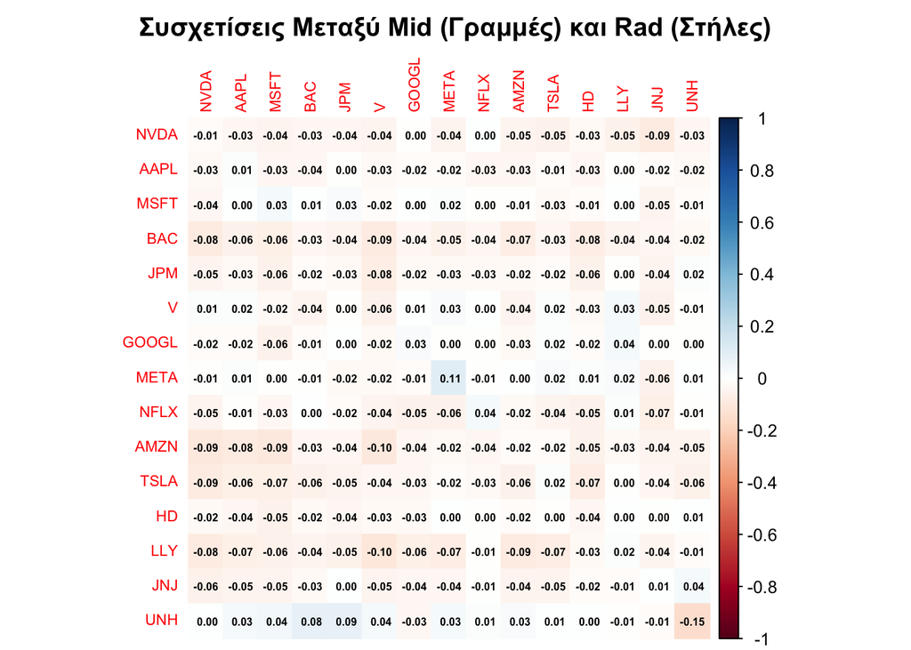

```r
# Οπτικοποίηση με ένα ενιαίο Heatmap / Correlation Plot
if(!require(corrplot)) install.packages("corrplot")
library(corrplot)

corrplot(cor_mid_vs_rad, method = "color",
         title = "Συσχετίσεις Μεταξύ Mid (Γραμμές) και Rad (Στήλες)",
         mar = c(0, 0, 2, 0), tl.cex = 0.7, addCoef.col = "black", number.cex = 0.5)
```

Αρχικά, με μπλε χρώμα παρουσιάζουμε τα ιστογράμματα των midpoints (κέντρων) κάθε ανεξάρτητης μεταβλητής, ενώ με κόκκινο χρώμα παρουσιάζουμε τα ιστογράμματα των radii (ακτίνων) κάθε ανεξάρτητης μεταβλητής.

’Επειτα στα boxplots φαίνεται ότι ο τεχνολογικός κλάδος είναι ο πιο ασταθής κλάδος, καθώς παρουσιάζει πολλές τιμές που βρίσκονται πολύ μακριά από το πορτοκαλί κουτί. Αντίθετα ο κλάδος της υγείας παρουσιάζει την μεγαλύτερη σταθερότητα, πιθανότατα γιατί δεν υπάρχουν πολλές έντονες μεταβολές στον τομέα της υγείας καθημερινά, όπως υπάρχουν στον τεχνολογικό τομέα, στον οποίο οι ραγδαίες εξελίξεις μέσω ειδήσεων ή/και κρυπτονομισμάτων μπορεί να επηρεάσουν σε τεράστιο βαθμό τις μετοχές κάποιες τεχνολογικής εταιρείας, όπως για παράδειγμα της NVDA, η αξία της οποίας έχει πολλαπλασιαστεί στα τελευταία χρόνια.

Τέλος, στον πίνακα συσχετίσεων μεταξύ mid και rad, βλέπουμε τιμές που βρίσκονται πολύ κοντά στο 0 και τα χρώματα των τετραγώνων είναι πολύ ανοιχτά, το οποίο υποδηλώνει ελάχιστη έως και μηδενική συσχέτιση μεταξύ των κέντρων και των ακτίνων. ’Αρα μπορούμε με σιγουριά να πούμε ότι δεν υπάρχει καμία αρνητική ή θετική συσχέτιση μεταξύ των κέντρων και των ακτίνων σε καμία μεταβλητή.

```r
# ==============================================================================
# Β2: Interval Linear Regression (Center Method - Billard & Diday)
# ==============================================================================

# 1. Ορισμός των Y (DIA)
Y_mid_pure <- as.numeric(all_returns[["DIA"]][rownames(df_mid), "DIA.mid"])
Y_rad_pure <- as.numeric(all_returns[["DIA"]][rownames(df_rad), "DIA.rad"])

# 2. Δημιουργία των σωστών Data Frames
data_mid_correct <- data.frame(Target = Y_mid_pure, df_mid)
data_rad_correct <- data.frame(Target = Y_rad_pure, df_rad)

# 3. Εκτέλεση των μοντέλων
model_mid_correct <- lm(Target ~ ., data = data_mid_correct)
model_rad_correct <- lm(Target ~ ., data = data_rad_correct)

# 4. Εκτύπωση αποτελεσμάτων
cat("==================================================================\n")
cat("Αποτελέσματα υποδείγματος κέντρων (Model Mid))\n")
```

```
## Αποτελέσματα υποδείγματος κέντρων (Model Mid))
```

```r
cat("==================================================================\n")
print(summary(model_mid_correct))
```

```
##
## Call:
## lm(formula = Target ~ ., data = data_mid_correct)
##
## Residuals:
##        Min         1Q     Median         3Q        Max
## -0.0138980 -0.0016747  0.0000666  0.0016391  0.0102652
##
## Coefficients:
##               Estimate Std. Error t value Pr(>|t|)
## (Intercept) -8.956e-05  8.518e-05  -1.051  0.29336
## NVDA         1.609e-02  4.561e-03   3.527  0.00044 ***
## AAPL         6.973e-02  8.567e-03   8.139 1.20e-15 ***
## MSFT         7.710e-02  9.516e-03   8.102 1.59e-15 ***
## BAC          7.710e-02  1.126e-02   6.850 1.30e-11 ***
## JPM          1.531e-01  1.269e-02  12.067  < 2e-16 ***
## V            1.004e-01  1.035e-02   9.698  < 2e-16 ***
## GOOGL        4.871e-03  6.873e-03   0.709  0.47863
## META        -5.914e-03  4.411e-03  -1.341  0.18026
## NFLX         7.536e-03  4.094e-03   1.841  0.06594 .
## AMZN         2.553e-02  6.353e-03   4.019 6.30e-05 ***
## TSLA         2.104e-03  3.533e-03   0.596  0.55162
## HD           1.371e-01  9.121e-03  15.029  < 2e-16 ***
## LLY          1.653e-02  5.590e-03   2.957  0.00318 **
## JNJ          9.489e-02  1.253e-02   7.571 8.49e-14 ***
## UNH          7.913e-02  5.319e-03  14.877  < 2e-16 ***
## ---
## Signif. codes:  0 '***' 0.001 '**' 0.01 '*' 0.05 '.' 0.1 ' ' 1
##
## Residual standard error: 0.002678 on 985 degrees of freedom
## Multiple R-squared:  0.849,  Adjusted R-squared:  0.8467
## F-statistic: 369.3 on 15 and 985 DF,  p-value: < 2.2e-16
```

```r
cat("\n==================================================================\n")
cat("Αποτελέσματα υποδείγματος ακτίνων (Model Rad)\n")
```

```
## Αποτελέσματα υποδείγματος ακτίνων (Model Rad)
```

```r
cat("==================================================================\n")
print(summary(model_rad_correct))
```

```
##
## Call:
## lm(formula = Target ~ ., data = data_rad_correct)
##
## Residuals:
##        Min         1Q     Median         3Q        Max
## -0.0071956 -0.0008609  0.0000542  0.0009006  0.0049044
##
## Coefficients:
##               Estimate Std. Error t value Pr(>|t|)
## (Intercept) -0.0024634  0.0001683 -14.639  < 2e-16 ***
## NVDA         0.0122553  0.0066480   1.843  0.06556 .
## AAPL         0.0973490  0.0120071   8.108 1.52e-15 ***
## MSFT         0.1032668  0.0156853   6.584 7.45e-11 ***
## BAC          0.0536182  0.0135272   3.964 7.91e-05 ***
## JPM          0.1368174  0.0148115   9.237  < 2e-16 ***
## V            0.0854004  0.0138408   6.170 9.95e-10 ***
## GOOGL        0.0156487  0.0117443   1.332  0.18302
## META         0.0057269  0.0098474   0.582  0.56099
## NFLX         0.0134034  0.0077569   1.728  0.08432 .
## AMZN         0.0195695  0.0124447   1.573  0.11615
## TSLA         0.0147958  0.0056507   2.618  0.00897 **
## HD           0.1374072  0.0129500  10.611  < 2e-16 ***
## LLY          0.0068319  0.0084919   0.805  0.42129
## JNJ          0.0728679  0.0159543   4.567 5.57e-06 ***
## UNH          0.0065003  0.0091348   0.712  0.47688
## ---
## Signif. codes:  0 '***' 0.001 '**' 0.01 '*' 0.05 '.' 0.1 ' ' 1
##
## Residual standard error: 0.001457 on 985 degrees of freedom
## Multiple R-squared:  0.8208, Adjusted R-squared:  0.8181
## F-statistic: 300.8 on 15 and 985 DF,  p-value: < 2.2e-16
```

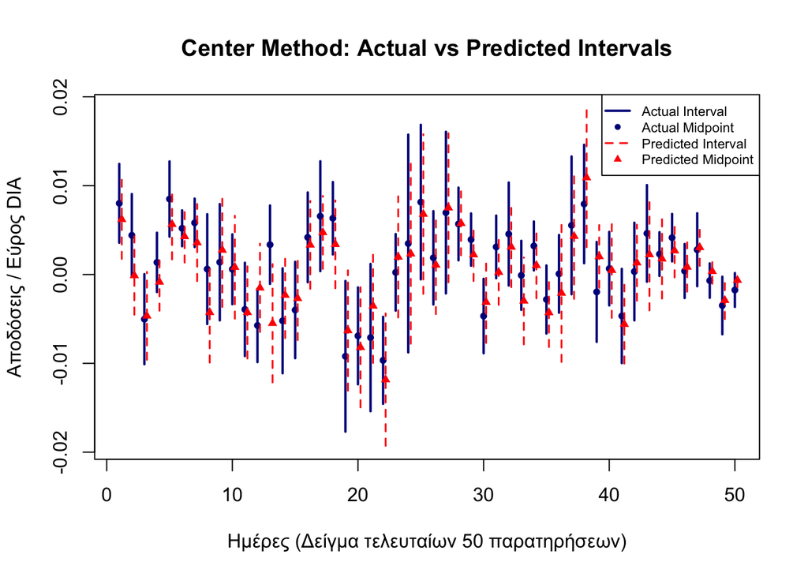

```r
# 5.Παρουσίαση Γραφήματος: Predicted vs Actual Intervals

# Υπολογισμός των προβλεπόμενων τιμών από τα διορθωμένα μοντέλα
pred_mid <- predict(model_mid_correct)
pred_rad <- predict(model_rad_correct)

# Κατασκευή των πραγματικών και προβλεπόμενων ορίων (Low, High)
actual_low  <- Y_mid_pure - Y_rad_pure
actual_high <- Y_mid_pure + Y_rad_pure
pred_low    <- pred_mid - pred_rad
pred_high   <- pred_mid + pred_rad

# Επιλέγουμε τις τελευταίες 50 ημέρες για να είναι το γράφημα απόλυτα ευανάγνωστο
n_view <- 50
idx <- (length(Y_mid_pure) - n_view + 1):length(Y_mid_pure)

# Αρχικό άδειο γράφημα με τα σωστά όρια στους άξονες
plot(1:n_view, type = "n",
     ylim = c(min(c(actual_low[idx], pred_low[idx])), max(c(actual_high[idx], pred_high[idx]))),
     xlab = "Ημέρες (Δείγμα τελευταίων 50 παρατηρήσεων)",
     ylab = "Αποδόσεις / Εύρος DIA",
     main = "Center Method: Actual vs Predicted Intervals")

# Σχεδίαση των Πραγματικών Διαστημάτων (Actual) με Μπλε κάθετες γραμμές
segments(1:n_view, actual_low[idx], 1:n_view, actual_high[idx], col = "darkblue", lwd = 2)
# Σχεδίαση των Πραγματικών Κέντρων (Actual Midpoints) με Μπλε τελείες
points(1:n_view, Y_mid_pure[idx], col = "darkblue", pch = 16, cex = 0.8)

# Σχεδίαση των Προβλεπόμενων Διαστημάτων (Predicted) με Κόκκινες διακεκομμένες γραμμές (λίγο μετατοπισμένες δεξιά για να μην πέφτουν ακριβώς από πάνω)
segments((1:n_view) + 0.2, pred_low[idx], (1:n_view) + 0.2, pred_high[idx], col = "red", lty = 2, lwd = 1.5)
# Σχεδίαση των Προβλεπόμενων Κέντρων (Predicted Midpoints) με Κόκκινες τελείες
points((1:n_view) + 0.2, pred_mid[idx], col = "red", pch = 17, cex = 0.8)

# Προσθήκη Υπομνήματος (Legend)
legend("topright", legend = c("Actual Interval", "Actual Midpoint", "Predicted Interval", "Predicted Midpoint"),
       col = c("darkblue", "darkblue", "red", "red"),
       lty = c(1, NA, 2, NA), pch = c(NA, 16, NA, 17), lwd = c(2, NA, 1.5, NA), cex = 0.7)
```

Και στα δύο μοντέλα ο συντελεστής R-Squared, είναι αρκετά υψηλός. Για ακρίβεια, στο μοντέλο για τα κέντρα των μετοχών έχει την τιμή 0.84, ενώ στην τιμή για τις ακτίνες των μετοχών έχει την τιμή 0.82, η οποία είναι προφανώς, ελάχιστα χαμηλότερη.

Οι λόγοι που συνήθως ο συντελεστής R-squared, παρουσιάζει πολύ χαμηλότερες τιμές στα μοντέλα των ακτίνων (rad), σε σχέση με τα μοντέλα των κέντρων (mid), είναι ο θόρυβος που μπορεί να εμπεριέχεται στα δεδομένα χρηματοοικονομικών αγορών και η αδυναμία ενός γραμμικού μοντέλου να εκλάβει τις μη-γραμμικές σχέσεις που επηρεάζουν τις ακτίνες (rad) της κάθε μετοχής.

Στο γράφημα Actual vs Predicted Intervals, παρατηρούμε ότι οι κόκκινες γραμμές, οι οποίες αντιπροσωπεύουν τις προβλέψεις για τις τελευταίες 50 ημέρες, έχουν βρεθεί πάρα πολύ κοντά στις πραγματικές τιμές, το οποίο δείχνει την ικανοποιητική ακρίβεια του Interval Linear Regression μοντέλου.

```r
# ==============================================================================
# Β3: Principal Component Analysis στα mid
# ==============================================================================

X_mid <- df_mid

# 1. Εκτέλεση Κλασικής PCA στα Midpoints (όπως δίνεται στην εκφώνηση)
pca_mid <- prcomp(X_mid, center = TRUE, scale. = TRUE)

cat("==================================================================\n")
cat("Αποτελέσματα PCA στα mid values\n")
```

```
## Αποτελέσματα PCA στα mid values
```

```r
cat("==================================================================\n")
print(summary(pca_mid))
```

```
## Importance of components:
##                           PC1    PC2     PC3     PC4     PC5     PC6    PC7
## Standard deviation     2.2386 1.3009 1.06264 0.98762 0.92339 0.89804 0.8677
## Proportion of Variance 0.3341 0.1128 0.07528 0.06503 0.05684 0.05377 0.0502
## Cumulative Proportion  0.3341 0.4469 0.52217 0.58720 0.64404 0.69781 0.7480
##                            PC8     PC9    PC10    PC11    PC12    PC13    PC14
## Standard deviation     0.81757 0.78851 0.74374 0.71970 0.67610 0.65933 0.59335
## Proportion of Variance 0.04456 0.04145 0.03688 0.03453 0.03047 0.02898 0.02347
## Cumulative Proportion  0.79257 0.83402 0.87090 0.90543 0.93590 0.96488 0.98835
##                           PC15
## Standard deviation     0.41795
## Proportion of Variance 0.01165
## Cumulative Proportion  1.00000
```

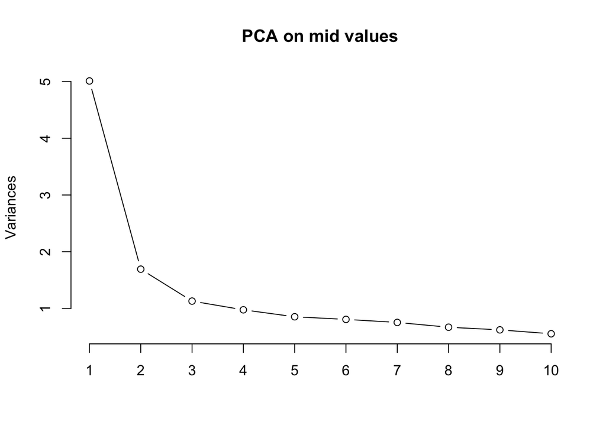

```r
# 2. Scree Plot (όπως ζητείται)
screeplot(pca_mid, type = "lines", main = "PCA on mid values")
```

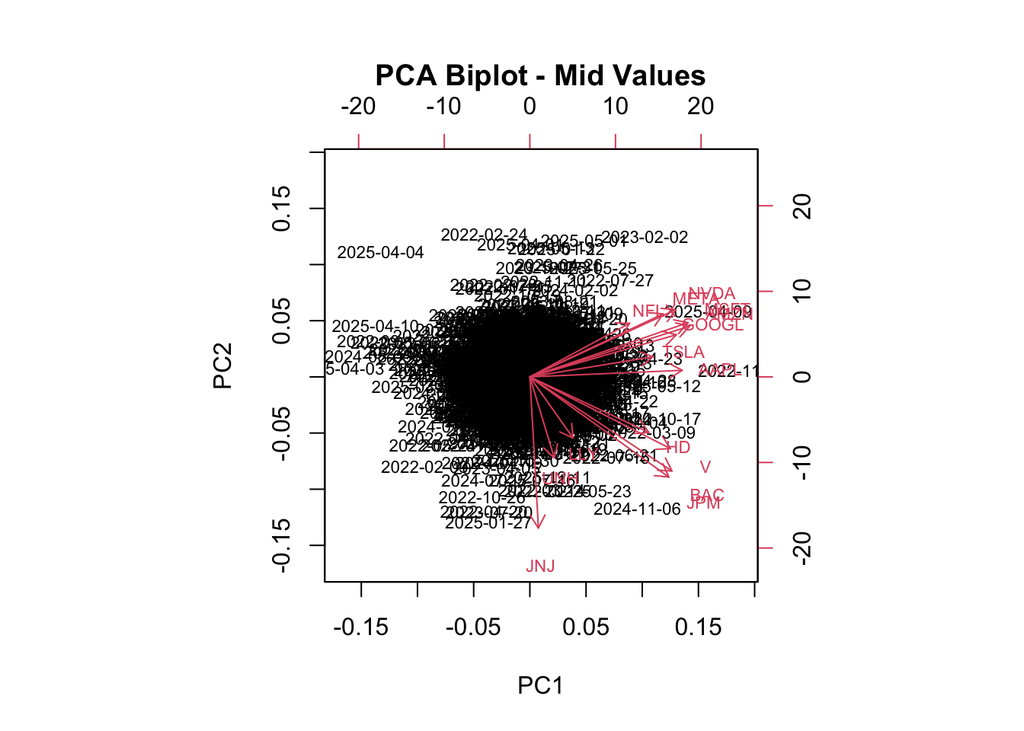

```r
# 3. Biplot για την οπτικοποίηση των φορτίσεων (loadings) των μετοχών
biplot(pca_mid, main = "PCA Biplot - Mid Values", cex = 0.7)
```

Παρατηρούμε μεγάλες ομοιότητες μεταξύ του Principal Component Analysis που έγινε στο ερώτημα Α4 και του Principal Component Analysis που έγινε σε αυτό το ερώτημα. Οι ομοιότητες αυτές, ευθύνονται στο γεγονός ότι το κέντρο του ημερήσιου εύρους, παρουσιάζει πολύ καλά την ημερήσια τάση μιας μετοχής και μέσα σε αυτό συμπεριλαμβάνονται και η τιμή κλεισίματος μιας μετοχής. Παρατηρούμε, λοιπόν ότι υπάρχει κοινό ποσοστό της διασποράς στα περισσότερα components, με μία μικρή διαφορά στο πρώτο component, όπου το ποσοστό της διασποράς έχει μειωθεί από 0.4 σε 0.33. Άρα, μέσω του Principal Component Analysis που έχει γίνει στα midpoints, έχουμε καταλήξει ότι υπάρχει μεγάλη ομοιότητα μεταξύ των τιμών κλεισίματος και των τιμών του κέντρου του ημερήσιου εύρους των μετοχών, το οποίο είναι το επιθυμητό αποτέλεσμα, αφού θέλουμε τα midpoints να αντιπροσωπεύουν, ως ένα βαθμό, τις τιμές κλεισίματος των μετοχών (Θα ήταν δηλαδή παράξενο να βλέπαμε τελείως διαφορετικά ποσοστά στο PCA στα mid).

Β4. Interval Factor Analysis (βιβλιογραφική εργασία)

1. Βιβλιογραφική αναζήτηση (Douzal-Chouakria & Diday, 2007)

Το βιβλίο Principal Component Analysis for Interval-Valued Observations, αποτελεί σταθμό για την Διαστηματική Ανάλυση Δεδομένων. Οι συγγραφείς επέκτειναν τις κλασικές μεθόδους μείωσης διάστασης, εισάγοντας μαθηματικές προσεγγίσεις που επιτρέπουν τη διατήρηση της εσωτερικής δομής των διαστημάτων (κέντρο και εύρος) κατά τη στατιστική ανάλυση. Στο πλαίσιο του Factor Analysis, η έρευνα επικεντρώνεται στο πώς οι λανθάνοντες παράγοντες μπορούν να ερμηνέυσουν τη μεταβλητότητα των διαστημάτων, λαμβάνοντας υπόψη ότι κάθε παρατήρηση δεν εκφράζεται απλώς από ένα σημείο x, αλλά από ένα ορθογώνιο υπέρ-κύβο (hyper-rectangle) στον πολυδιάστατο χώρο. ’Ετσι προτάθηκαν νέες μέθοδοι από τους συγγραφείς για την Principal Component Analysis, όπως η μέθοδος των κορυφών (vertices method) και η μέθοδος των κέντρων (center’s method), οι οποίες έχουν εφαρμοστεί με επιτυχία στην PCA, όμως η επέκτασή τους στην Factor Analysis αντιμετωπίζει σοβαρούς μαθηματικούς περιορισμούς.

2. Προβλήματα ταυτοποίησης (identifaction) σε Interval FA Στην κλασική Παραγοντική Ανάλυση, το πρόβλημα ταυτοποίησης (identification problem) σχετίζεται με το αν υπάρχει μοναδική λύση για τους παράγοντες και τις φορτίσεις (loadings). Όμως στην Interval FA, αυτό το πρόβλημα περιπλέκεται δραματικά, καθώς η περιστροφή των παραγόντων, οι οποίοι πλέον εκφράζονται σε μορφές “κύβων” και όχι σημείων, καθιστά την εύρεση της μοναδικής βέλτιστης λύσης εξαιρετικά δύσκολη. Τα διαστήματα ορίζονται από ανισότητες και πολλές φορές η προσπάθεια εύρεσης λύσης που να ικανοποιεί όλους τους περιορισμούς, οδηγεί σε ένα σύστημα εξισώσεων το οποίο δεν έχει μοναδική λύση.
3. Γιατί η Interval FA είναι δυσκολότερη από την Interval PCA;

Διαφορετική Φιλοσοφία: Η PCA είναι μια μέθοδος περιγραφικής στατιστικής που απλώς αναδιατάσσει τη συνολική διασπορά σε νέους άξονες (κύριες συνιστώσες). Δεν υποθέτει κάποιο στατιστικό υπόδειγμα. Αντίθετα, η FA είναι μια μέθοδος μοντελοποίησης που προσπαθεί να διαχωρίσει τη συνολική διασπορά σε κοινή διασπορά και ειδική/μοναδική διασπορά για κάθε μεταβλητή.

Μοντελοποίηση του Σφάλματος: Στην Interval PCA, εφαρμόζουμε τη γεωμετρία των διαστημάτων απευθείας στους πίνακες διακύμανσης-συνδιακύμανσης. Στην Interval FA, πρέπει να ορίσουμε και να μοντελοποιήσουμε τη διαστηματική φύση του σφάλματος. Ο ορισμός ενός «διαστήματος σφάλματος» που να συμπεριφέρεται ορθά στατιστικά είναι μαθηματικά εξαιρετικά πολύπλοκο.

Υπολογιστικοί Περιορισμοί: Για την Interval PCA υπάρχουν έτοιμες γεωμετρικές λύσεις (όπως η μέθοδος των κορυφών - Vertices Method ή η Center Method των Billard & Diday). Αντίθετα, η Interval FA απαιτεί επαναληπτικές αλγοριθμικές μεθόδους μεγίστης πιθανοφάνειας (Maximum Likelihood) προσαρμοσμένες σε ανισότητες διαστημάτων, οι οποίες συχνά αποτυγχάνουν να συγκλίνουν σε πραγματικά χρηματοοικονομικά δεδομένα.

```r
# ==============================================================================
# Β5. SEM - Structural Equation Modeling
# ==============================================================================

# 1. Φόρτωση του απαραίτητου πακέτου lavaan
if(!require(lavaan)) install.packages("lavaan")
library(lavaan)

# 2. Προετοιμασία των δεδομένων: Ενώνουμε το Y_mid και τις μετοχές X_mid
data_sem <- data.frame(Y_mid = Y_mid_pure, df_mid)

# 3. Ορισμός του μοντέλου SEM
sem_model <- '
  TechFactor =~ NVDA + AAPL + MSFT
  Y_mid ~ TechFactor
'

# 4. Εφαρμογή του μοντέλου SEM
sem_fit <- sem(sem_model, data = data_sem)
# 5. Εμφάνιση αποτελεσμάτων με τα Fit Measures
cat("==================================================================\n")
cat("Αποτελέσματα μοντέλου SEM (Structural Equation Modeling))\n")
```

```
## Αποτελέσματα μοντέλου SEM (Structural Equation Modeling))
```

```r
cat("==================================================================\n")
summary(sem_fit, fit.measures = TRUE, standardized = TRUE)
```

```
## lavaan 0.6-19 ended normally after 92 iterations
##
##   Estimator                                         ML
##   Optimization method                           NLMINB
##   Number of model parameters                         8
##
##   Number of observations                          1001
##
## Model Test User Model:
##
##   Test statistic                                48.135
##   Degrees of freedom                                 2
##   P-value (Chi-square)                           0.000
##
## Model Test Baseline Model:
##
##   Test statistic                              1258.478
##   Degrees of freedom                                 6
##   P-value                                        0.000
##
## User Model versus Baseline Model:
##
##   Comparative Fit Index (CFI)                    0.963
##   Tucker-Lewis Index (TLI)                       0.889
##
## Loglikelihood and Information Criteria:
##
##   Loglikelihood user model (H0)              12326.358
##   Loglikelihood unrestricted model (H1)      12350.426
##
##   Akaike (AIC)                              -24636.717
##   Bayesian (BIC)                            -24597.447
##   Sample-size adjusted Bayesian (SABIC)     -24622.855
##
## Root Mean Square Error of Approximation:
##
##   RMSEA                                          0.152
##   90 Percent confidence interval - lower         0.116
##   90 Percent confidence interval - upper         0.190
##   P-value H_0: RMSEA <= 0.050                    0.000
```

[output cut: 16 more lines]

```
##     AAPL              0.540    0.031   17.259    0.000    0.009    0.682
##     MSFT              0.576    0.031   18.341    0.000    0.010    0.751
##
## Regressions:
##                    Estimate  Std.Err  z-value  P(>|z|)   Std.lv  Std.all
##   Y_mid ~
##     TechFactor        0.311    0.017   18.344    0.000    0.005    0.751
##
## Variances:
##                    Estimate  Std.Err  z-value  P(>|z|)   Std.lv  Std.all
##    .NVDA              0.000    0.000   18.074    0.000    0.000    0.561
##    .AAPL              0.000    0.000   17.577    0.000    0.000    0.535
##    .MSFT              0.000    0.000   15.146    0.000    0.000    0.436
##    .Y_mid             0.000    0.000   15.135    0.000    0.000    0.436
##     TechFactor        0.000    0.000   10.643    0.000    1.000    1.000
```

Σχολιασμός των fit measures: Comparative Fit Index (CFI): Ο συγκεκριμένος δείκτης αναφέρεται στην καταλληλότητα του συγκεκριμένου μοντέλου SEM. Άρα η υψηλή τιμή (0.963) που αντιστοιχεί στο CFI του συγκεκριμένου SEM δηλώνει ότι το μοντέλο μπορεί να ερμηνεύσει και να καλύψει μεγάλο ποσό της συσχέτισης των δεδομένων, και συγκεκριμένα, 96%.

Root Mean Squared Error of Approximation (RMSEA): Προφανώς, αφού πρόκειται για σφάλμα σχετικό με το μοντέλο που υλοποιήθηκε, θέλουμε η τιμή να πλησιάζει το 0, όσο περισσότερο είναι εφικτό. Το συγκεκριμένο μοντέλο παρουσιάζει RMSEA = 0.152, το οποίο θεωρείται υψηλό και πιθανότατα προκλήθηκε από την απώλεια των υπόλοιπων 12 μετοχών.

Standardized Root Mean Square Residual (SRMR): Η τιμή του SRMR είναι 0.035, το οποίο είναι πολύ χαμηλό και αυτό είναι θετικό για το μοντέλο γιατί παρουσιάζει πολύ μικρά σφάλματα.

Συμπέρασμα για την επίδραση του τεχνολογικού παράγοντα στον δείκτη DIA: Από την τιμή Estimate = 0.311, του μοντέλου, συμπεραίνουμε ότι ο δείκτης της Dow Jones (DIA), επηρεάζεται θετικά όταν υπάρχει άνοδος στον τεχνολογικό παράγοντα, δηλαδή κάθε μονάδα αύξησης του τεχνολογικού παράγοντα, αυξάνει τον δείκτη DIA κατά 0.311. Επίσης, το p-value = 0.000 επιβεβαιώνει την στατιστική σημαντικότητα των αποτελεσμάτων του μοντέλου.

Γ1. Πίνακας σύγκρισης μεθόδων

Μέθοδος: Κλασική Διάστημα (mid) Διάστημα (rad) R-Squared/Explained Variance: 0.8897 0.8467 0.8181 Αριθμός σημαντικών Χ: 11 11 8

Ερμηνευσιμότητα μοντέλων: Αρχικά η κλασική μέθοδος της γραμμικής παλινδρόμησης μπορεί να θεωρηθεί από τις πιο ερμηνεύσιμες μεθόδους, καθώς ένας άνθρωπος μπορεί να καταλάβει πολύ εύκολα την σημασία κάθε ανεξάρτητης μεταβλητής και πώς κάθε μία από αυτές συμβάλλει στην παραγωγή της τιμής της εξαρτημένης μεταβλητής. Το “πρόβλημα” της κλασικής μεθόδου, είναι ότι λαμβάνει κάθε μετοχή μόνο ως μία τιμή κλεισίματος, άρα χάνει ένα κομμάτι της πληροφορίας, επειδή δεν λαμβάνει υπόψη την κινητικότητα που μπορεί να υπάρχει μέσα σε μία ολόκληρη μέρα. Για αυτό έρχονται οι διαστηματικές μέθοδοι mid & rad, οι οποίες μπορεί να θεωρηθούν πιο σύνθετες άρα και λιγότερο ερμηνεύσιμες, όμως λαμβάνουν υπόψη όλη την κινητικότητα των μετοχών μέσα σε μία ημέρα και έτσι σχηματίζουν μία τιμή που αντιστοιχεί στο κέντρο των τιμών που πήρε μία μετοχή ημερήσια και ένα διάστημα που αντιστοιχεί στην ακτίνα μία μετοχής, δηλαδή το εύρος των τιμών που έχει πάρει ημερήσια. Παρόλο που χάνεται ένα σημαντικό κομμάτι της ερμηνευσιμότητας, και το μοντέλο γίνεται πιο δυσνόητο από τους ανθρώπους, είναι σαφές ότι αυτές οι δύο μέθοδοι προσθέτουν πολύ σημαντικές νέες πληροφορίες στα μοντέλα και έτσι δικαιολογείται η απώλεια ενός μέρους της ερμηνευσιμότητας.

Γ2. Ερμηνεία αποτελεσμάτων

Στην κλασική ανάλυση των τιμών κλεισίματος, οι τιμές που αναδείχθηκαν ως οι σημαντικότερες, είναι οι εξής: NVDA, AAPL, MSFT, BAC, JPM, V, AMZN, HD, LLY, JNJ. UNH. Παρατηρούμε ότι αυτές οι 11 μετοχές ανήκουν κυρίως στους τεχνολογικούς και χρηματοοικονομικούς κλάδους, οι οποίοι όπως έχουμε προαναφέρει έχουν την ισχυρότερη επίδραση στον δείκτη της Dow Jones.

Περνόντας στην ανάλυση των κέντρων (mid), παρατηρήθηκε ότι και πάλι ο αριθμός των σημαντικών μετοχών ήταν 11 και οι σημαντικές μετοχές ήταν προφανώς οι ίδιες 11 με αυτές της κλασικής ανάλυσης.

Τέλος, στην ανάλυση των ακτίνων (rad), παρατηρήθηκε ότι μόλις 8 μετοχές θεωρήθηκαν σημαντικές και αυτές ήταν οι εξής: AAPL, MSFT, BAC, JPM, V, TSLA, HD, JNJ. Σχετικά με την προβλεψιμότητα της αστάθειας της αγοράς, η ανάλυση των ακτίνων αποδεικνύει ότι η αστάθεια που υπάρχει στις μετοχές μέσα σε μία ημέρα μπορεί να θεωρηθεί σε μεγάλο βαθμό συστηματική και προβλέψιμη, αφού το μοντέλο data_rad_correct, που χρησιμοποιήθηκε στην ανάλυση των ακτίνων (rad), είχε πολύ υψηλό R-squared (0.81).

Γ3. Κριτική και περιορισμοί

Αρχικά, ο βασικός περιορισμός της ανάλυσης και των μοντέλων που διαμορφώθηκαν, είναι ότι τα συγκεκριμένα μοντέλα λειτουργούν έχοντας υποθέσει ότι υπάρχουν γραμμικές σχέσεις μεταξύ των μεταβλητών, τόσο στην κλασική, όσο και στην διαστηματική ανάλυση. Κάτι τέτοιο προφανώς δεν ισχύει, διότι οι τιμές των μετοχών μέσα σε μία μέρα μπορούν να επηρεαστούν από πολλά πράγματα τα οποία δεν εκφράζονται μέσω γραμμικών σχέσεων όπως για παράδειγμα τις ειδήσεις και τα απότομα σοκ στις τιμές τους. Ένας ακόμα περιορισμός που αξίζει να αναφερθεί είναι το σχετικά μικρό δείγμα των μεταβλητών, καθώς ο δείκτης της Dow Jones αποτελείται από 30 μετοχές, το οποίο σημαίνει ότι η ανάλυση έχει γίνει με 15 λιγότερες μετοχές.

Με περισσότερο χρόνο και υπολογιστική ισχύ, θα μπορούσαμε να αντιμετωπίσουμε το πρόβλημα των γραμμικών σχέσεων που προαναφέρθηκε, καθώς θα μπορούσαμε να υλοποιήσουμε κάποιο μη-γραμμικό διαστηματικό μοντέλο, όπως για παράδειγμα τα Interval Support Vector Machines, τα οποία λειτουργούν “τιμωρώντας” τις τιμές που βρίσκονται εκτός ενός περιθωρίου που ορίζει ο αλγόριθμος, ή εναλλακτικά θα μπορούσε να υλοποιηθεί ο αλγόριθμος Interval-Valued Random Forest, ο οποίος υλοποιείται σε διαστηματικά μετεορολογικά δεδομένα, και δουλεύει όπως και ο αλγόριθμος Random Forest, επιλέγοντας δηλαδή την βέλτιστη λύση ανάμεσα σε εκατοντάδες διαφορετικά μονοπάτια/δάση.

Όσον αφορά την διαστηματική προσέγγιση και την βελτίωση της, μία πρόταση είναι η χρήση της μεθόδου των κορυφών(vertices method) που πρότειναν οι Douzal-Chouakria & Diday, καθώς η συγκεκριμένη μέθοδος αναλύει γεωμετρικά όλο των υπέρ-κύβο των δεδομένων, προσφέροντας καλύτερη μαθηματική ακρίβεια και σιγουριά στις προβλέψεις των μοντέλων.